# Small FA RNA-seq quality control

2018-04-18

```r
library(knitr)
library(ggplot2)

# Set seed for reproducibility
set.seed(1454944673L)

opts_chunk[["set"]](
    autodep = TRUE,
    bootstrap.show.code = FALSE,
    cache = TRUE,
    cache.lazy = TRUE,
    dev = c("png", "pdf"),
    error = TRUE,
    fig.height = 6,
    fig.retina = 2L,
    fig.width = 6,
    highlight = TRUE,
    message = FALSE,
    prompt = TRUE,
    # formatR required for tidy code
    tidy = TRUE,
    warning = TRUE)

theme_set(
    theme_light(base_size = 12L))
theme_update(
    legend.justification = "center",
    legend.position = "bottom")
```

```r
R> library(isomiRs)
R> library(DEGreport)
R> library(ggplot2)
R> library(bcbioSmallRna)
R> theme_set(theme_light(base_size = 12))
R>
R> out_dir <- params$outputDir
R> data_out <- file.path(out_dir, "data")
R> res_out <- file.path(out_dir, "results", "counts")
R> sapply(list(res_out, data_out), dir.create, recursive = TRUE, showWarnings = FALSE)
```

```
## [1] FALSE FALSE
```

```r
R> # bcbioSmallRnaDataSet
R> bcb_name <- load(params$bcb)
R> bcb <- get(bcb_name, inherits = FALSE)
```

# Exploratory analysis

In this section we will see descriptive figures about quality of the data, reads with adapter, reads mapped to miRNAs, reads mapped to other small RNAs.

## Size distribution

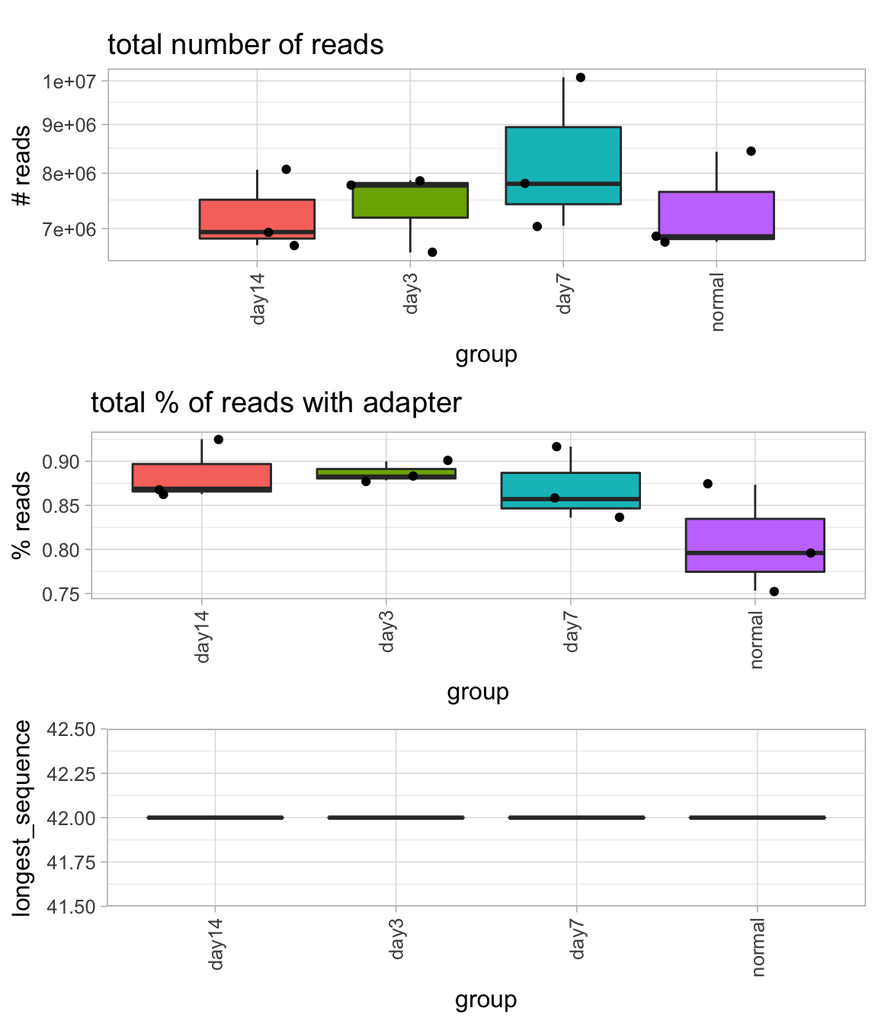

```r
R> bcbSmallSize(bcb)
```

```r
R> bcbSmallSizeDist(bcb)
```

```
## Error in `[[<-.data.frame`(`*tmp*`, "pct", value = numeric(0)): replacement has 0 rows, data has 312
```

## miRNA

A microRNA (abbreviated miRNA) is a small non-coding RNA molecule (containing about 22 nucleotides) found in plants, animals and some viruses, that functions in RNA silencing and post-transcriptional regulation of gene expression.[https://en.wikipedia.org/wiki/MicroRNA]

### Total miRNA expression annotated with mirbase

miRBase is one of the database that contains the reference miRNA sequences. We used this database to annotate the sequences with [miraligner](http://seqcluster.readthedocs.io/mirna_annotation.html)

```r
R> bcbSmallMicro(bcb)
```

```
## Error in FUN(X[[i]], ...): object 'group' not found
```

### Clustering of samples

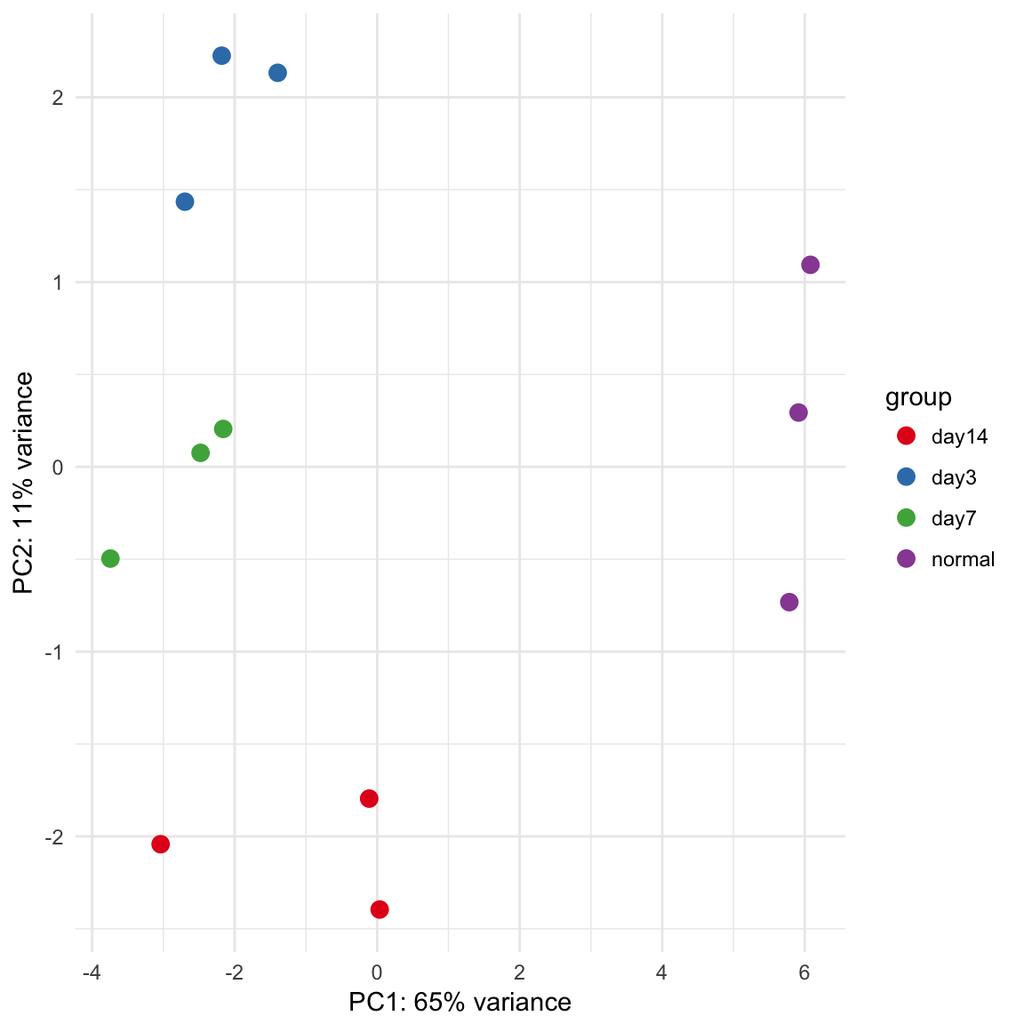

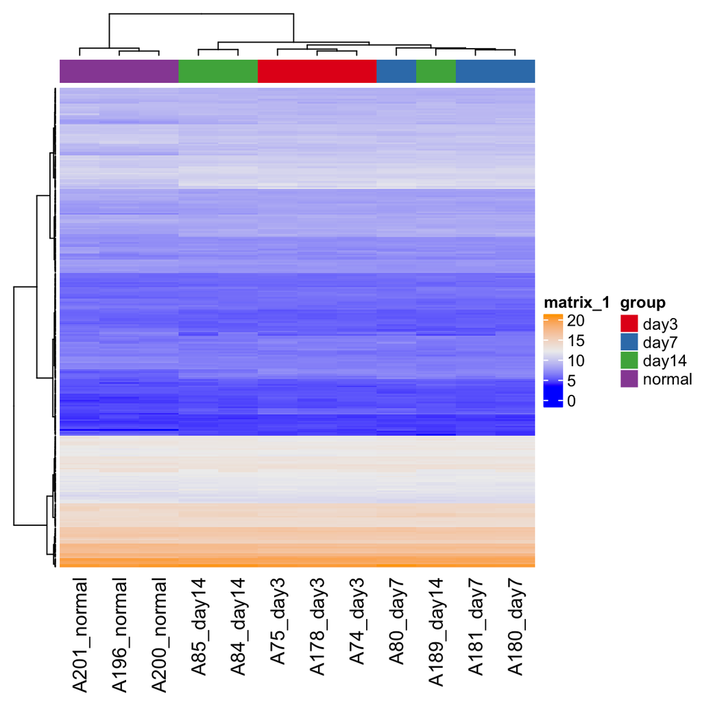

```r
R> bcbSmallPCA(bcb)
```

## isomiRs

isomiR is a term coined by Morin et al. to refer to those sequences that have variations with respect to the reference MiRNA sequence. [https://en.wikipedia.org/wiki/IsomiR]

There are 5 different types of isomiRs:

- ref: perfect match to the sequence on the database
- t3: nucleotides changes at 3’
- t5: nucleotides changes at 5’
- add: nucleotides addition at the 3’
- mism: putatives SNPs

[figure not shown]

```r
R> ids <- bcbio(bcb, "isomirs")
R> isoPlot(ids, type = "all", column = "time")
```

```
## Error in `[.data.frame`(metadata, , column): undefined columns selected
```

## Small RNA clusters

We use [seqcluster](http://seqcluster.readthedocs.io/getting_started.html) to identify any type of small RNA. It generates a list of clusters of small RNA sequences, their genome location, their annotation and the abundance in all the sample of the project. The next figure explain the algorithm used for that and the way to use it for differential expression analyses.

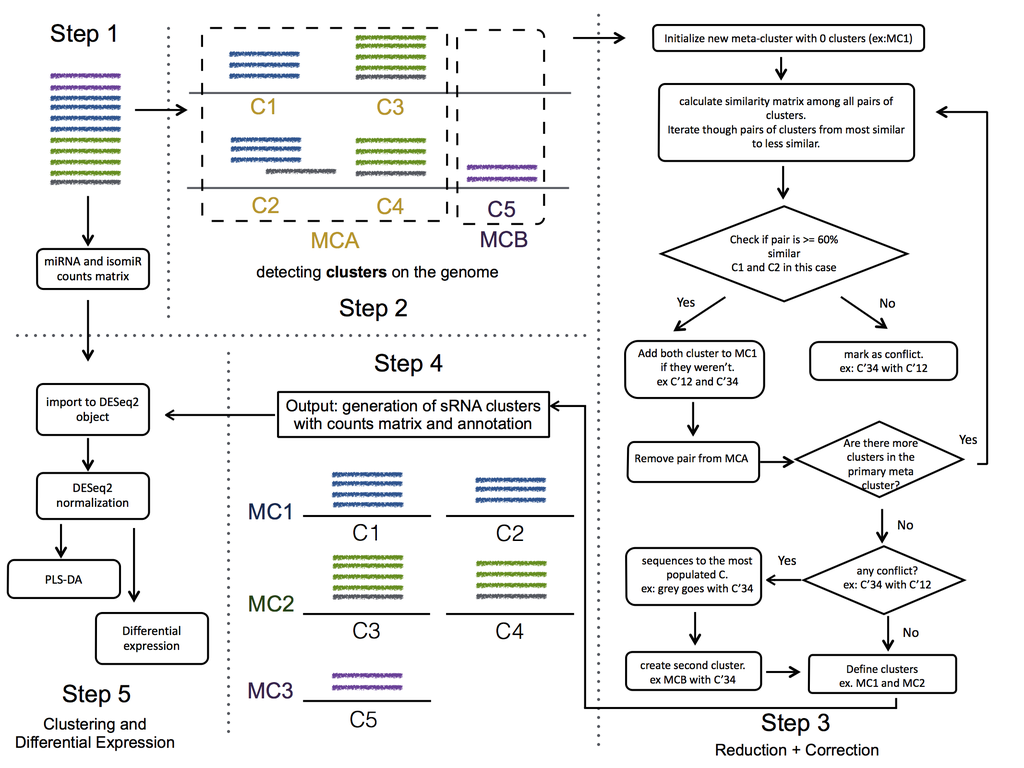

This file generated by seqcluster, `seqcluster.db`, can be used with the page `reader.html` after downloading from [here](https://github.com/lpantano/seqclusterViz/archive/master.zip).

See example:

[figure not shown]

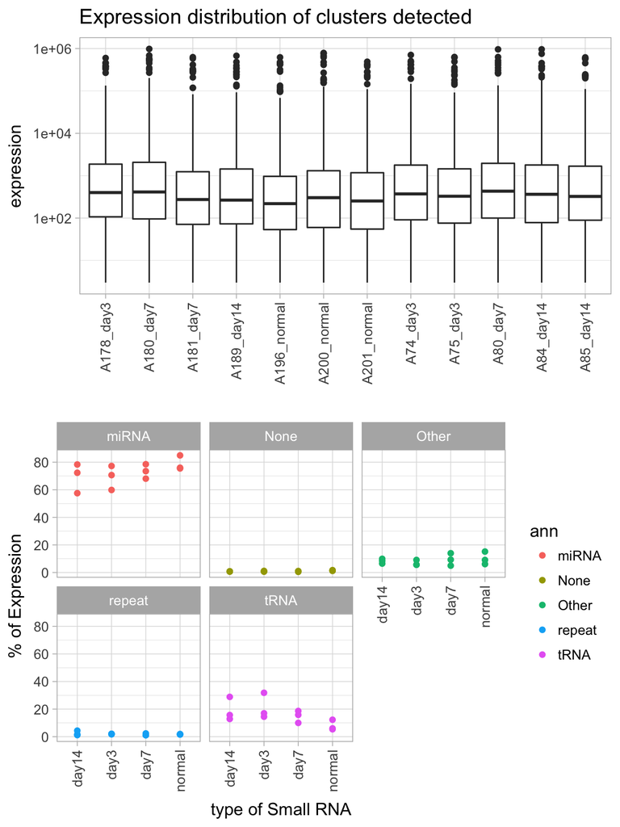

```r
R> bcbSmallCluster(bcb)
```

### Clustering of samples

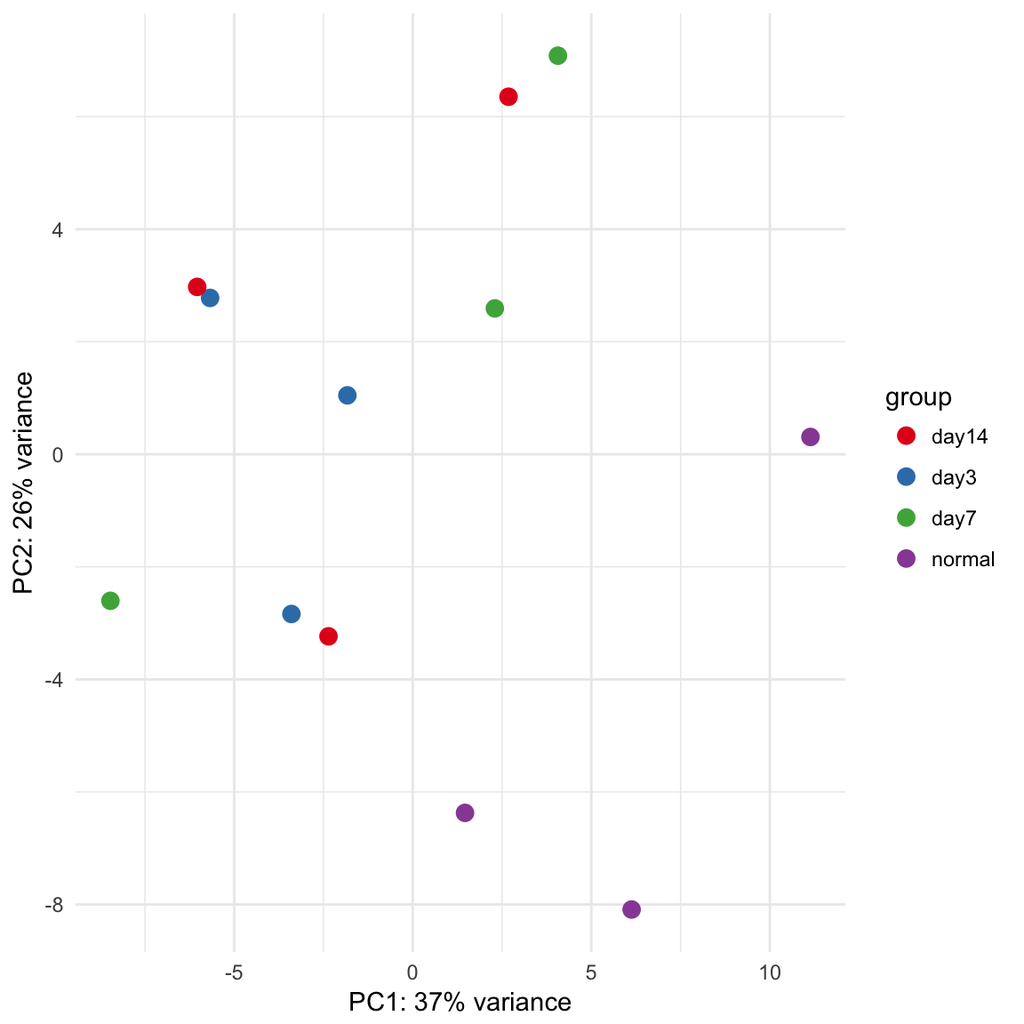

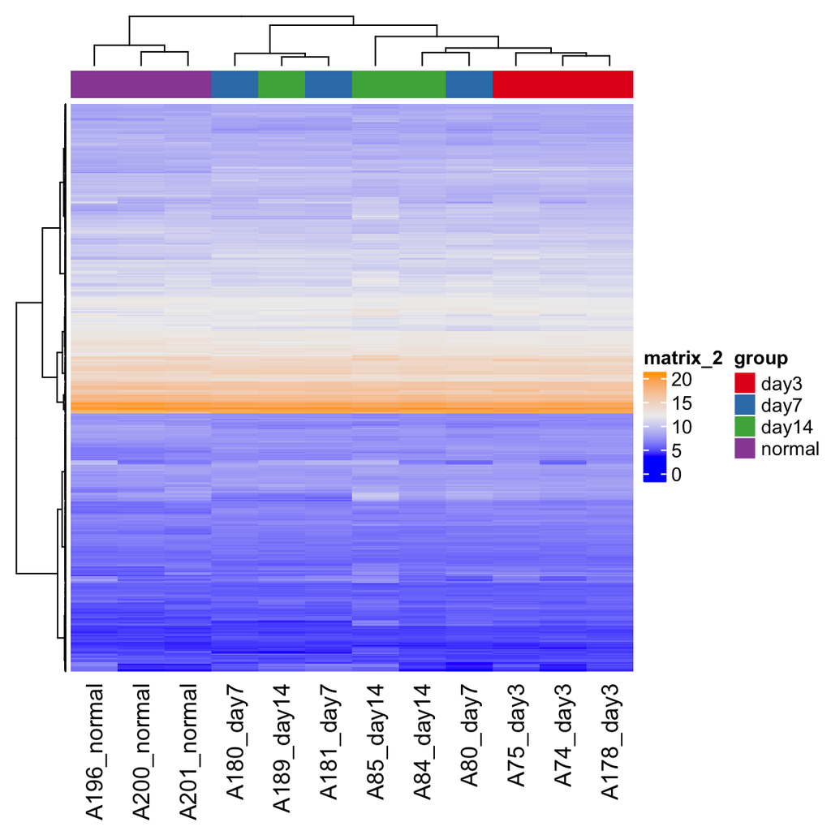

```r
R> bcbSmallPCA(bcb, "cluster")
```

```r
R> library(rio)
R> library(tibble)
R> mirna(bcb, "rlog") %>% as.data.frame() %>% rownames_to_column("mirna") %>% export(file.path(res_out,
+     "mirna_rlog.csv"))
```